# Saving Figures in RStudio

This is a simple tutorial on how to save a plot as an image file in R/RStudio.

# Data

The data for this demo include various measurements of redbacked salamander (*Plethodon cinereus*) collected at several sites in Ithaca, NY.

You can download the data file here: mander.csv

These variables within the data set include:

- Date of collection
- Collector
- Year of collection (2014)
- Season of collection (limited to Fall for this dataset)
- Site (A, B, C, D)
- Snout-to-vent length (SVL) in mm
- Total length in mm
- Sex (male, female, or unknown)

# Creating a figure

Suppose I have loaded the salamander into a variable called `mander`.

```r
head(mander)
```

```
##        Date  Collector Year Season Site SVL Total_length    Sex
## 1  5-Sep-14 Sutherland 2014   Fall    A  36           72 female
## 2  4-Oct-14 Sutherland 2014   Fall    A  46           83 female
## 3  4-Oct-14 Sutherland 2014   Fall    A  42           89 female
## 4  4-Oct-14 Sutherland 2014   Fall    A  34           75 female
## 5  4-Oct-14 Sutherland 2014   Fall    A  37           80 female
## 6 18-Oct-14 Sutherland 2014   Fall    A  40           79 female
```

Using ggplot, I’ll make a conditional boxplot of SVL by Site and Sex. Don’t worry if you don’t know what that means, the focus of this walkthrough is on saving the plot to a file.

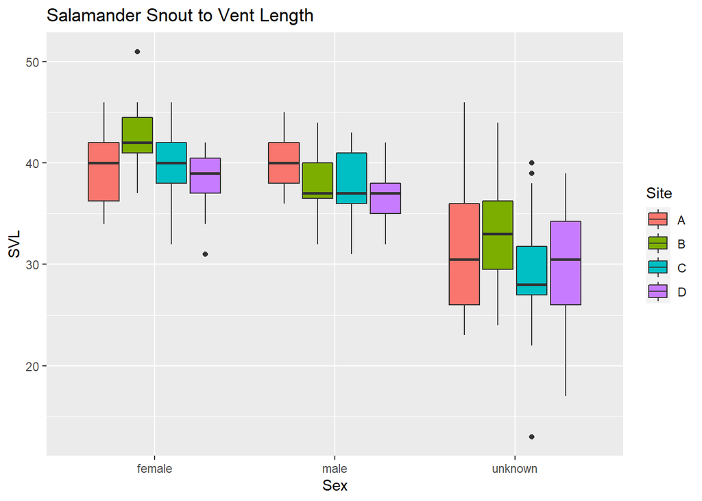

```r
ggplot(mander, aes(x = Sex, y = SVL, fill = Site)) +
  geom_boxplot() +
  ggtitle("Salamander Snout to Vent Length")
```

The Plots pane in my RStudio session now looks like this:

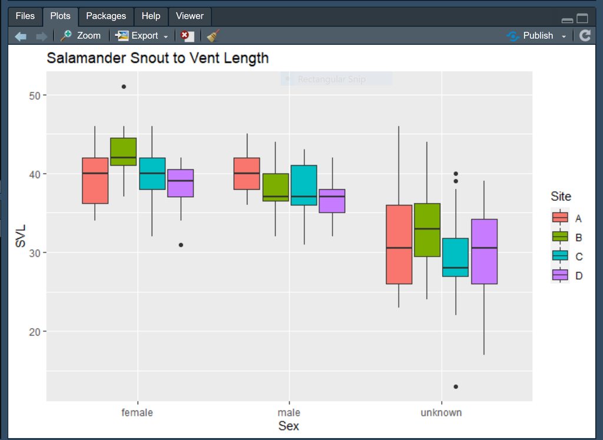

# Save Method 1: Export Button

Notice that above the plot there is a button that says *Export*.

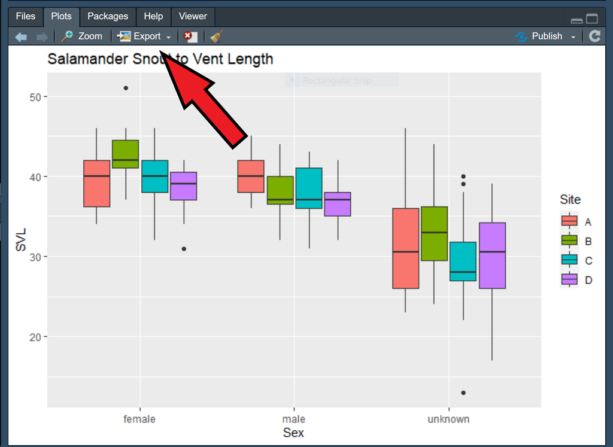

Click there and choose whether you want to save the image as a `.pdf` or `.png` file.

# Save Method 2: Programmatic

You can also save a figure directly using code in R. I prefer this method because you can more easily specify the options that you want to use for the image.

The image will be saved as the `filename` that you provide. The image will be saved in your **current working directory**.

- I **strongly suggest** you use the here package in conjunction with an RProject to help specify exactly where you want to save the file and avoid working directory headaches!

The syntax is slightly different than what you’re used to:

- You have to use `png()` on the line before your plotting code.
- The code to build your plot comes next.
- You have to place `dev.off()` on the line after your plotting code.

```r
# This tells R to create an empty image file:
png(filename = "salamander_boxplot.png")

# These lines create the plot.
# You won't see the plot in the RStudio plot window.
ggplot(mander, aes(x = Sex, y = SVL, fill = Site)) +
  geom_boxplot() +
  ggtitle("Salamander Snout to Vent Length")

# This tells R to write the graphical data to the image file and save it.
dev.off()
```

`png()` has lots of options (see the help entry). For example, you can specify the height and width of the output image (in pixels).

I’ll now have a file called **salamander_boxplot.png** in my current working directory.

There are related functions for saving files to other raster and vector formats like jpg, tiff, pdf, and eps.

- Check the help entry for these functions because some of the options may differ slightly from `png()`

The best way to learn is to try it out on one of your own plots!